# Methods Comp Notes

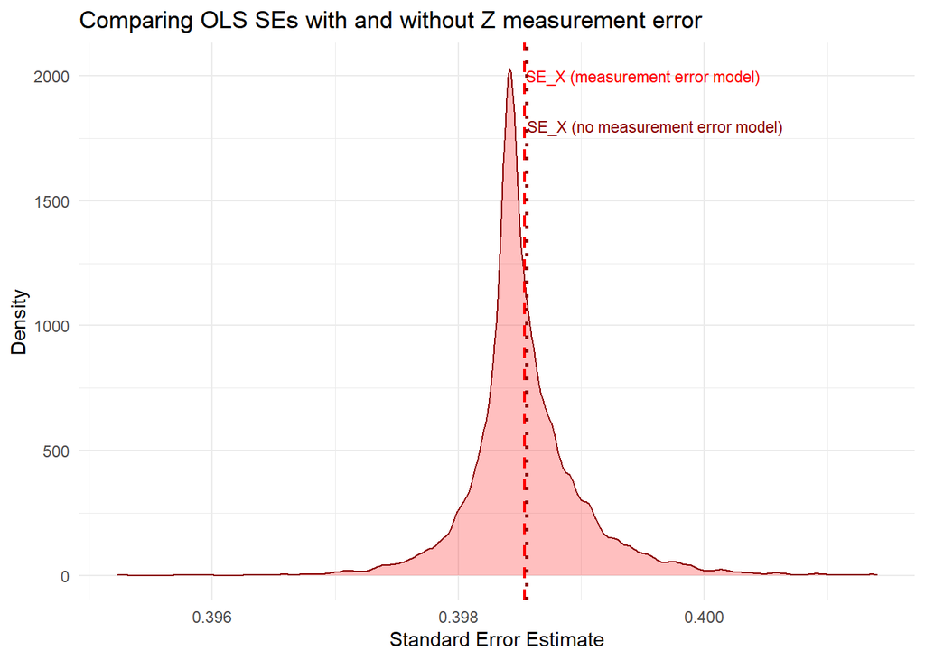

```r
sim.q1.4 %>%
  drop_na() %>%
  ggplot(aes()) +
    geom_density(aes(x=SE_X_em), fill="red", alpha=0.25, color="darkred") +
    #geom_density(aes(x=SE_Z_em), fill="blue", alpha=0.25, color="darkblue") +
    geom_vline(aes(xintercept=mean(SE_X_em)), color="red", lwd=.8,
               linetype="dashed") +
    geom_vline(aes(xintercept=summary(model_q1.1)$coefficients[2,2]),
               color="darkred", linetype="dotted", lwd=1) +
    # geom_vline(aes(xintercept=mean(SE_Z_em)), color="blue", lwd=.8,
    #            linetype="dashed") +
    # geom_vline(aes(xintercept=summary(model_q1.1)$coefficients[3,2]),
    #            linetype="dotted", color="darkblue", lwd=1) +
    labs(x="Standard Error Estimate", y="Density",
         title="Comparing OLS SEs with and without Z measurement error") +
    theme_minimal() +
    # annotate("text", x=-.01, y=100, label="Z (measurement error model)",
    #          color="blue", size=3) +
    # annotate("text", x=.1, y=100, label="Z (no measurement error model)",
    #          color="darkblue", size=3) +
    annotate("text", x=0.3995, y=2000, label="SE_X (measurement error model)",
             color="red",size=3) +
    annotate("text", x=0.3996, y=1800, label="SE_X (no measurement error model)",
             color="darkred", size=3)
```

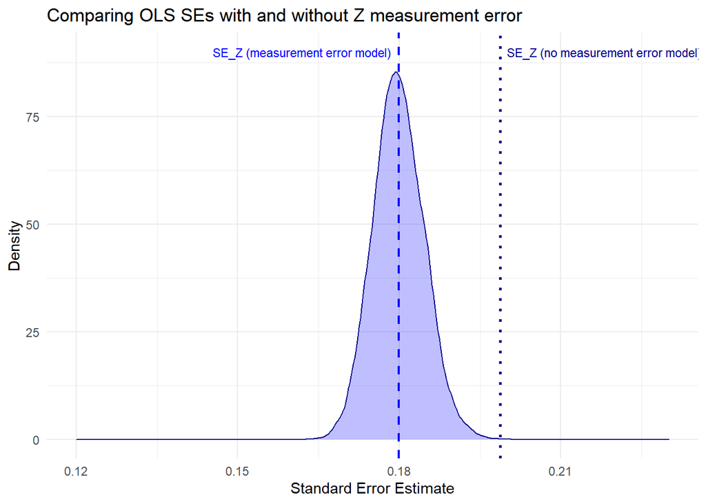

```r
sim.q1.4 %>%
  drop_na() %>%
  ggplot(aes()) +
    geom_density(aes(x=SE_Z_em), fill="blue", alpha=0.25, color="darkblue") +
    geom_vline(aes(xintercept=mean(SE_Z_em)), color="blue", lwd=.8,
               linetype="dashed") +
    geom_vline(aes(xintercept=summary(model_q1.1)$coefficients[3,2]),
               linetype="dotted", color="darkblue", lwd=1) +
    xlim(c(0.12,0.23)) +
    labs(x="Standard Error Estimate", y="Density",
         title="Comparing OLS SEs with and without Z measurement error") +
    theme_minimal() +
    annotate("text", x=0.162, y=90, label="SE_Z (measurement error model)",
             color="blue", size=3) +
    annotate("text", x=.218, y=90, label="SE_Z (no measurement error model)",
             color="darkblue", size=3)
```

The next two figures plot the distribution and mean (dashed line) of standard error estimates from the simulation for X and Z, respectively. The standard error estimates for the OLS model from part 1.3 are plotted with dotted lines. There is no effect of measurement error for Z on the standard error estimates for X but measurement error on Z does bias its standard error estimates toward zero.

5. Suppose that Q (included in your dataset) is a valid instrument for $Z$. Repeat your analysis from 1.3 appropriately and explain your new conclusion.

Assuming $Q$ affects $Y$ only through $Z$ we can perform an two stage least squares regression as follows:

```r
# Estimate the first stage regression: Z ~ Q
model_stage1 <- lm(Z ~ Q, data=df_q1)

# Grab the fitted values from the first stage regression and attach to our
# dataset
df_q1$ZonQ <- model_stage1$fitted.values

# Perform the second stage regression replacing Z with our fitted values from
# stage 1:
model_stage2 <- lm(Y ~ X + ZonQ, data=df_q1)

# Because lm doesn't calculate instrumental standard errors correctly we can
# re-estimate our IV regression with ivreg from the AER package:
model_stage2_ivreg <- ivreg(Y ~ X + Z | X + Q, data=df_q1)

# Compare these models' estimates to that of part 1.3
modelsummary(list("Non-IV Model"=model_q1.1,
                  "IV Model (lm)"=model_stage2,
                  "IV Model (ivreg)"=model_stage2_ivreg), stars=T)
```

|  | Non-IV Model | IV Model (lm) | IV Model (ivreg) |
| --- | --- | --- | --- |
| (Intercept) | 7.072*** | 7.197*** | 7.197*** |
|  | (0.421) | (0.427) | (0.444) |
| X | 0.175 | 0.221 | 0.226 |
|  | (0.399) | (0.398) | (0.414) |
| Z | 0.046 |  | -0.793 |
|  | (0.199) |  | (0.573) |
| ZonQ |  | -0.792 |  |
|  |  | (0.551) |  |
| Num.Obs. | 250 | 250 | 250 |
| R2 | 0.001 | 0.009 | -0.071 |
| R2 Adj. | -0.007 | 0.001 | -0.080 |
| AIC | 1660.8 | 1658.8 |  |
| BIC | 1674.9 | 1672.9 |  |
| Log.Lik. | -826.403 | -825.387 |  |
| F | 0.127 | 1.136 |  |

+ p < 0.1, * p < 0.05, ** p < 0.01, *** p < 0.001

We can see that using $Q$ as an instrument for $Z$ yields a coefficient that is the opposite sign and further from zero than using $Z$ itself, however, because the standard errors remain large, we cannot draw any substantively different conclusion from the IV model as opposed to the non-IV model estimated in part 1.3.

6. This is a time-series dataset. What problems may arise when conducting this type of analysis? What are some of the solutions you might use to address these problems.

The primary concern with performing OLS regression on time series is the presence of serial autocorrelation. This violates the assumption required by OLS that observations are independent of one another. This can cause errors to be correlated over time and bias the estimated standard errors.

One way to address this is to use autoregressive (AR) or autoregressive moving average (ARMA) models rather than ordinary least squares. AR and ARMA models use previous values as predictors to account for serial autocorrelation and the resulting bias in standard errors. However, these models assume stationarity of the time series data so tests such as the ADF, KWSS, and PP statistical tests must be conducted first and differencing/other data transformation/decomposition may be necessary to meet the conditions necessary for these models.

## 2 MLE

For this question, we will be using a replication dataset from a forthcoming article in the American Journal of Political Science, “Differences in Men’s and Women’s Policing Behavior: Evidence from Traffic Stops” by Kelsey Shoub, Katelyn E. Stauffer, and Miyeon Song. Shoub, Strauffer, and Song (Forthcoming) use data from over four million traffic stops in North Carolina and Florida to understand how gender is associated with the likelihood that an officer searches someone they have stopped at a traffic stop. You can find the full paper here: https://drive.google.com/file/d/1JyNzTF3lZq8N0blVahb7Zko3M5clPcHk/view and replication data here: https://dataverse.harvard.edu/dataset.xhtml?persistentId=doi:10.7910/DVN/QTUF6D.

For our purposes, we will be using a smaller version of their full analysis, looking at 2,712,478 traffic stops in Florida. Note that our analyses are simpler versions of what the authors do in the paper, so this is not an exact replication, though the conclusions are the same.

Download the data (sent to you) and load it into R. We are interested in exploring how whether a search occurred `search_occur` is associated with the officer’s gender `of_gender`, coded 1 for female and 0 for male.

1. In this question, we will model `search_occur` as a function of `of_gender` using logistic regression. Write down the data generating process for the logit model.

```r
# Warning: Loading this file crashes RStudio like half the time
df_q2 <- get(load("Methods_Comp_2021_Data/Question2Data.rdata"))
```

Our stochastic component is modeled as a Bernoulli distribution:

$$f_B(y_i;\theta_i)=\theta_i^{y_i}(1-\theta_i)^{1-y_i}=
\left\{
\begin{array}{ll}
\theta_i & y_i=1 \\
1-\theta_i & y_i=0
\end{array}
\right.$$

And our systematic component is:

$$\theta_i=\mathrm{logit}^{-1}(x_i^T\beta)=\frac{1}{1+e^{-x_i^T\beta}}$$

2. Derive the log-likelihood function (show your work).

We first define the joint probability distribution of $i$ independent Bernoulli trials by taking the product of our stochastic component defined in part 1:

$$Pr(y|\theta)=\prod_{i=1}^n \theta_i^{y_i}(1-\theta_i)^{1-y_i}$$

We define this joint probability distribution as our likelihood function, $\mathcal{L}(\theta|y)$:

$$\mathcal{L}(\theta|y)=\prod_{i=1}^n \theta_i^{y_i}(1-\theta_i)^{1-y_i}$$

Taking the natural logarithm our product becomes a sum and, applying log laws, we arrive at the log likelihood:

$$\ln(\mathcal{L}(\theta|y))=\ln[\prod_{i=1}^n \theta_i^{y_i}(1-\theta_i)^{1-y_i}]$$
$$\ln(\mathcal{L}(\theta|y))=\sum_{i=1}^n\ln[ \theta_i^{y_i}(1-\theta_i)^{1-y_i}]$$
$$\ln(\mathcal{L}(\theta|y))=\sum_{i=1}^n y_i\ln(\theta_i) + (1-y_i)\ln(1-\theta_i)$$
where $\theta_i=\mathrm{logit}^{-1}(x_i^T\beta)=\frac{1}{1+e^{-x_i^T\beta}}$ as defined above.

3. Program the log-likelihood function in `R` and optimize for the coefficients on `of_gender`. Report your coefficients and standard errors in a table.

We find the MLE of the above log likelihood with `R` as follows:

```r
#function for optimization of logit
binreg<- function(X,y,method="BFGS"){
  X<- cbind(1,X)

  # Get the log-likelihood
  negLL<- function(b,X,y){
    p<-as.vector(1/(1+exp(-X %*% b)))

    return(-sum(y*log(p) + (1-y)*log(1-p)))
  }

  # Get the gradient (score function)
  gradient<- function(b,X,y){
    p <- as.vector(1/(1+exp(-X %*% b)))

    return(-apply(((y - p)*X), 2, sum))
  }

  # Pass our data, log-likelihood, and gradient to optim()
  # which will find the maximum likelihood
  results<- optim(par=rep(0,ncol(X)),
                  fn=negLL,
                  gr=gradient,
                  hessian=T,
                  method=method,
                  X=X,
                  y=y)

  # Pull out the stuff we want
  list(coefficients=results$par,
       stderr=sqrt(diag(solve(results$hessian))),
       var=solve(results$hessian),
       deviance=2*results$value,
       converged=results$convergence==0)
}

mlebin.fit<-binreg(X=df_q2$of_gender, y=df_q2$search_occur)

# Get our logit coefficients
round(mlebin.fit$coefficients,3)
```

```
## [1] -5.293 -1.497
```

```r
# Get out logit standard errors
round(mlebin.fit$stderr,3)
```

```
## [1] 0.009 0.067
```

```r
# Double check against R's baked in estimation
fit.glm <- glm(search_occur ~ of_gender,
               family = binomial(link = "logit"),
               data = df_q2)
summary(fit.glm, signif.stars=FALSE)
```

```
##
## Call:
## glm(formula = search_occur ~ of_gender, family = binomial(link = "logit"),
##     data = df_q2)
##
## Deviance Residuals:
##     Min       1Q   Median       3Q      Max
## -0.1001  -0.1001  -0.1001  -0.1001   3.6854
##
## Coefficients:
##              Estimate Std. Error z value Pr(>|z|)
## (Intercept) -5.292826   0.008947 -591.55   <2e-16 ***
## of_gender   -1.497044   0.066862  -22.39   <2e-16 ***
## ---
## Signif. codes:  0 '***' 0.001 '**' 0.01 '*' 0.05 '.' 0.1 ' ' 1
##
## (Dispersion parameter for binomial family taken to be 1)
##
##     Null deviance: 162465  on 2712477  degrees of freedom
## Residual deviance: 161616  on 2712476  degrees of freedom
## AIC: 161620
##
## Number of Fisher Scoring iterations: 9
```

```r
# Looks good so let's put our estimates into a nice table
kable(cbind(Term=c("Intercept", "of_gender"),
            Estimate=round(mlebin.fit$coefficients,3),
            "Std. Err."=round(mlebin.fit$stderr,3)),
      caption="Logit Model")
```

Logit Model

| Term | Estimate | Std. Err. |
| --- | --- | --- |
| Intercept | -5.293 | 0.009 |
| of_gender | -1.497 | 0.067 |

4. Simulate the expected probabilities of a search at a traffic stop given a female officer and given a male officer. Create a plot of the difference, including estimates of uncertainty. Interpret the result.

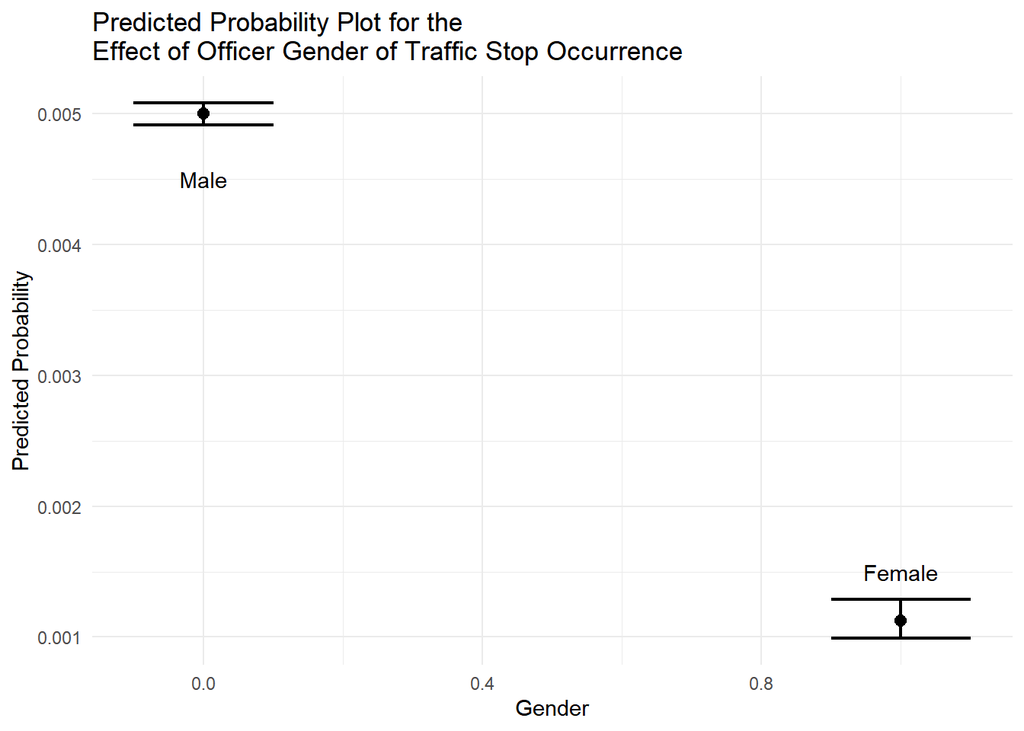

```r
# We want to know the difference in predicted probability
# of being pulled over when an officer is male vs. female


# Create a sequence of the range of values for the 96 vote share
gender.range <- c(0,1)

# Construct the male scenario
x.lo <- c(1, 0)
X.lo <- matrix(x.lo, nrow=length(x.lo), ncol=length(gender.range))
X.lo[2,] <- gender.range

# Construct the female scenario
x.hi <- c(1, 1)
X.hi <- matrix(x.hi, nrow=length(x.hi), ncol=length(gender.range))
X.hi[2,] <- gender.range

# Generate a multivariate normal distribution
B.tilde <- mvrnorm(1000, coef(fit.glm), vcov(fit.glm))

# Generate the predicted probabilities
s.lo <- inv.logit(B.tilde %*% X.lo)
s.hi <- inv.logit(B.tilde %*% X.hi)
s.lo <- apply(s.lo, 2, quantile, c(0.025, 0.5, 0.975))
s.hi <- apply(s.hi, 2, quantile, c(0.025, 0.5, 0.975))


# Now tidy the data and plot with ggplot
pred.prob.df <- data.frame(xrange=rep(gender.range,2),
                           y=c(s.lo[2,],s.hi[2,]),
                           conf.low = c(s.lo[1,], s.hi[1,]),
                           conf.high = c(s.lo[3,], s.hi[3,]),
                           scenario = rep(c("Male", "Female"),
                                          each=length(gender.range)))

ggplot(data=pred.prob.df, aes(x=xrange, y=y,
                              ymin=conf.low,
                              ymax=conf.high)) +
  geom_point(size=2.5) +
  geom_errorbar(width=0.2, size=0.8) +
  labs(x="Gender", y="Predicted Probability",
       title="Predicted Probability Plot for the\nEffect of Officer Gender of Traffic Stop Occurrence") +
  theme_minimal() +
  annotate("text", x=1, y=.0015, label="Female") +
  annotate("text", x=0, y=.0045, label="Male")
```

5. A critic of the paper says that years of service might confound the relationship between gender and searches at traffic stops. On average, female officers have fewer years of service. Include `officer_years_of_service` in your regression as a control variable. Repeat the analysis in 2.3 and report your coefficients and standard errors in a table.

```r
#function for optimization of logit
binreg<- function(X,y,method="BFGS"){
  X<- cbind(1,X)

  # Get the log-likelihood
  negLL<- function(b,X,y){
    p<-as.vector(1/(1+exp(-X %*% b)))

    return(-sum(y*log(p) + (1-y)*log(1-p)))
  }

  # Get the gradient (score function)
  gradient<- function(b,X,y){
    p <- as.vector(1/(1+exp(-X %*% b)))

    return(-apply(((y - p)*X), 2, sum))
  }

  # Pass our data, log-likelihood, and gradient to optim()
  # which will find the maximum likelihood
  results<- optim(par=rep(0,ncol(X)),
                  fn=negLL,
                  gr=gradient,
                  hessian=T,
                  method=method,
                  X=X,
                  y=y)

  # Pull out the stuff we want
  list(coefficients=results$par,
       stderr=sqrt(diag(solve(results$hessian))),
       var=solve(results$hessian),
       deviance=2*results$value,
       converged=results$convergence==0)
}

mlebin.fit<-binreg(X=cbind(df_q2$of_gender, df_q2$officer_years_of_service), y=df_q2$search_occur)

# Get our logit coefficients
round(mlebin.fit$coefficients,3)
```

```
## [1] -5.243 -1.484 -0.009
```

```r
# Get out logit standard errors
round(mlebin.fit$stderr,3)
```

```
## [1] 0.012 0.067 0.001
```

```r
# Double check against R's baked in estimation
fit.glm <- glm(search_occur ~ of_gender + officer_years_of_service,
               family = binomial(link = "logit"),
               data = df_q2)
summary(fit.glm, signif.stars=FALSE)
```

```
##
## Call:
## glm(formula = search_occur ~ of_gender + officer_years_of_service,
##     family = binomial(link = "logit"), data = df_q2)
##
## Deviance Residuals:
##     Min       1Q   Median       3Q      Max
## -0.1027  -0.1027  -0.1009  -0.0978   3.7257
##
## Coefficients:
##                           Estimate Std. Error  z value Pr(>|z|)
## (Intercept)              -5.242712   0.011514 -455.344  < 2e-16 ***
## of_gender                -1.484107   0.066888  -22.188  < 2e-16 ***
## officer_years_of_service -0.008857   0.001328   -6.671 2.53e-11 ***
## ---
## Signif. codes:  0 '***' 0.001 '**' 0.01 '*' 0.05 '.' 0.1 ' ' 1
##
## (Dispersion parameter for binomial family taken to be 1)
##
##     Null deviance: 162465  on 2712477  degrees of freedom
## Residual deviance: 161570  on 2712475  degrees of freedom
## AIC: 161576
##
## Number of Fisher Scoring iterations: 9
```

```r
# Looks good so let's put our estimates into a nice table
kable(cbind(Term=c("Intercept", "of_gender", "officer_years_of_service"),
            Estimate=round(mlebin.fit$coefficients,3),
            "Std. Err."=round(mlebin.fit$stderr,3)),
      caption="Logit Model")
```

Logit Model

| Term | Estimate | Std. Err. |
| --- | --- | --- |
| Intercept | -5.243 | 0.012 |
| of_gender | -1.484 | 0.067 |
| officer_years_of_service | -0.009 | 0.001 |

6. For each of 1 through 40 years of service, iterating by one year at a time, estimate the probability of a search at a traffic stop for a male and female officer. Plot your point estimates and confidence intervals on a plot where the x-axis is years of service, y-axis is predicted probability and there are two sets of points and confidence intervals – one for female and one for male officers. How would you respond to the critic?

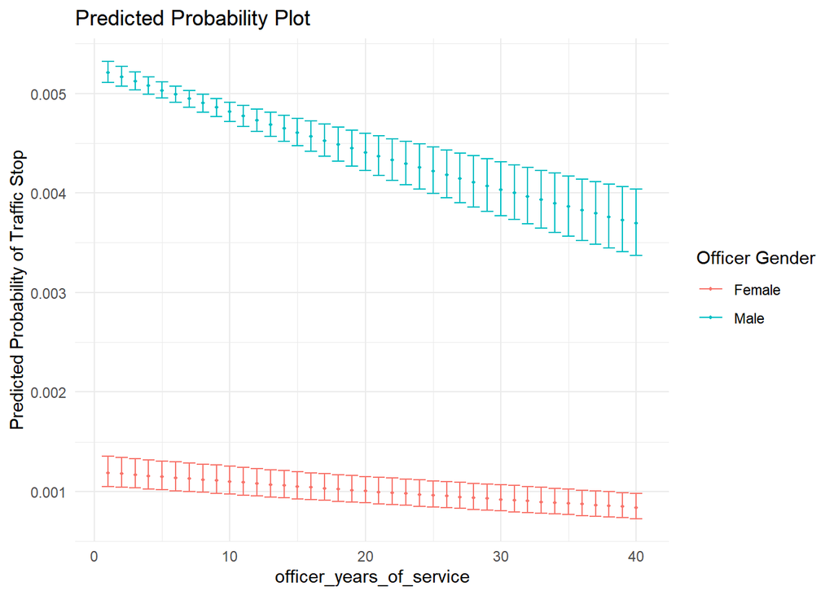

```r
# We want to know the difference in predicted probability of a traffic stop
# by a female vs male as a function of their years of service

# Create a sequence of the range of values for years of service
service.range <- seq(1,40,1)

# Construct the male scenario
x.lo <- c(1, 0, median(df_q2$officer_years_of_service)) # Democrat scenario
X.lo <- matrix(x.lo, nrow=length(x.lo), ncol=length(service.range))
X.lo[3,] <- service.range

# Construct the female scenario
x.hi <- c(1, 1, median(df_q2$officer_years_of_service)) # Republican scenario
X.hi <- matrix(x.hi, nrow=length(x.hi), ncol=length(service.range))
X.hi[3,] <- service.range

# Generate a multivariate normal distribution
B.tilde <- mvrnorm(1000, coef(fit.glm), vcov(fit.glm))

# Generate the predicted probabilities
s.lo <- inv.logit(B.tilde %*% X.lo)
s.hi <- inv.logit(B.tilde %*% X.hi)
s.lo <- apply(s.lo, 2, quantile, c(0.025, 0.5, 0.975))
s.hi <- apply(s.hi, 2, quantile, c(0.025, 0.5, 0.975))


# Now tidy the data and plot with ggplot
pred.prob.df <- data.frame(xrange=rep(service.range,2),
                           y=c(s.lo[2,],s.hi[2,]),
                           conf.low = c(s.lo[1,], s.hi[1,]),
                           conf.high = c(s.lo[3,], s.hi[3,]),
                           scenario = rep(c("Male", "Female"),
                                          each=length(service.range)))

ggplot(data=pred.prob.df, aes(x=xrange, y=y,
                              ymin=conf.low,
                              ymax=conf.high,
                              color=factor(scenario))) +
  geom_point(size=.8) +
  geom_errorbar() +
  labs(x="officer_years_of_service", y="Predicted Probability of Traffic Stop",
       title="Predicted Probability Plot", color="Officer Gender") +
  scale_fill_manual(labels=c("Male", "Female"),
                    values=c("blue", "red")) +
  theme_minimal()
```

Years of service does not appear to be a confounder in the relationship between gender and traffic stops. First, the model estimates in part 5 indicate that, regardless of gender, officers with more years of service are less likely to conduct a search. From the above plot we can see that, regardless of the years of service, a male officer is generally more likely to conduct a search than a female.

Further, while years of service may affect the dependent variable (and indeed it does have a significant affect according to our model in part 5), it does not intuitively make sense that years of service could somehow affect an officer’s gender. We should, in fact, be concerned that gender affecting the years of service, not the other way around.

# POLI 271 2022 Midterm

## Problem 1: Linear Regression

For this problem set, we will be replicating some work from our very own political science department,Hill, Seth J., and Thad Kousser. “Turning out unlikely voters? A field experiment in the top-two primary.” Political Behavior 38.2 (2016): 413-432. In this experiment, Hill and Kousser sent 150,000 letters to voters before California’s 2014 primary. The authors targeted the group of Californians who had turned out in general elections, but not in primaries.

In this question, we will see if these mailers increased turnout in the 2014 primary. Use the data turnout.csv posted on the course website for this analysis.

The variables of interest are: • `yvar`: whether or not a person turned out to vote in the primary • `mailer`: whether or not they received any mailer • `treatment.assign`: which mailer (if any) they received (see article for a description of the different mailer treatments). This variable is “Control” if they did not receive one. • `Party`: Party of the person who received the mailer

Use a linear regression model to estimate the effect of treatment assignment (treatment.assign) on turnout (yvar). To do this, you should create an indicator variable for each unique value of treatment assignment.

```r
# Load in the data and create our indicator variables
df_q1 <- read_csv("MLE_Midterm_Data/turnout.csv") %>%
  mutate(control=case_when(treatment.assign == "Control" ~ 1,
                           T ~ 0),
         treatment.top2=case_when(treatment.assign == "Top-two info" ~ 1,
                        T ~ 0),
         treatment.partisan=case_when(treatment.assign == "Partisan" ~ 1,
                        T ~ 0),
         treatment.election=case_when(treatment.assign == "Election info" ~ 1,
                        T ~ 0))
    # %>% sample_n(size=1000) # get a random subsamples so it doesn't take forever to
    #                     # run optim() later
```

1. Write out the stochastic and systematic components for this model.

Stochastic component: $Y\sim N(\theta;\sigma^2)=\frac{1}{\sigma\sqrt{2\pi}}e^{-\frac{(y-\mu)^2}{2\sigma^2}}$

Systematic component: A linear combination of $X$ (i.e. $\beta_0 + \beta_1 x_1 + \beta_2 x_2 + . . .$) where $X\in\mathbb{R}$, expressed as $\mu=\beta X$.

2. Derive the log-likelihood.

Our probability function is:

$$\mathrm{Pr}(Y=y)=\frac{1}{\sqrt{2\pi\sigma^2}}e^{-\frac{(y_i-\mu_i)^2}{2\sigma^2}}$$
We first construct the joint probability function by taking the product of the above for $n$ independent observations:

$$f_{\mathrm{joint}}(y_i|\mu;\sigma^2)=\prod_{i=1}^n \frac{1}{\sqrt{2\pi\sigma^2}}e^{-\frac{(y_i-\mu_i)^2}{2\sigma^2}}$$

We define this as our likelihood function:
$$\mathcal{L}=\prod_{i=1}^n \frac{1}{\sqrt{2\pi\sigma^2}}e^{-\frac{(y_i-\mu_i)^2}{2\sigma^2}}$$
We then take the natural log of both sides and simplify by applying log laws:

$$\ln\mathcal{L}=\ln[(\frac{1}{\sigma\sqrt{2\pi}})^n\prod_{i=1}^n e^{-\frac{(y_i-\mu_i)^2}{2\sigma^2}}]$$
$$\ln\mathcal{L}=\ln[\prod_{i=1}^n \frac{1}{\sqrt{2\pi\sigma^2}}e^{-\frac{(y_i-\mu_i)^2}{2\sigma^2}}]$$
$$\ln\mathcal{L}=\sum_{i=1}^n \ln[\frac{1}{\sqrt{2\pi\sigma^2}}e^{-\frac{(y_i-\mu_i)^2}{2\sigma^2}}]$$
$$\ln\mathcal{L}=\sum_{i=1}^n[-\frac{1}{2}\ln(2\pi)-\frac{1}{2}\ln(\sigma^2)-\frac{1}{2\sigma^2}(y_i-\mu_i)^2]$$

3. Optimize the model to find the maximum likelihood estimates for β and σ

```r
# Build our x
x <- as.matrix(cbind(1,
           df_q1 %>% select(treatment.top2,
                            treatment.partisan,
                            treatment.election)))
# Build our y
y <- df_q1$yvar

# Define a function that returns the (negative) log likelihood
negLL.OLS <- function(theta,y,x){
   n <- nrow(x)
   k <- ncol(x)
   beta <- theta[1:k]
   sigma2 <- theta[k+1]
   e <- y-x%*%beta
   LL<- -0.5*n*log(2*pi)-0.5*n*log(sigma2)-((t(e)%*%e)/(2*sigma2))
   return(-LL)
}

# Optimize the likelihood function and return our estimates
result <- optim(par=rep(1,ncol(x)+1), fn=negLL.OLS, method="BFGS", hessian=TRUE, y=y, x=x)

coefficients <- round(result$par[1:ncol(x)],3)
stderrs <- round(sqrt(diag(solve(result$hessian)))[1:ncol(x)],3)

# Check against lm
model_q1 <- lm(yvar ~ treatment.top2 + treatment.partisan + treatment.election, data = df_q1)
summary(model_q1)
```

```
##
## Call:
## lm(formula = yvar ~ treatment.top2 + treatment.partisan + treatment.election,
##     data = df_q1)
##
## Residuals:
##      Min       1Q   Median       3Q      Max
## -0.09838 -0.09312 -0.09312 -0.09312  0.90688
##
## Coefficients:
##                     Estimate Std. Error t value Pr(>|t|)
## (Intercept)        0.0931248  0.0001508 617.722  < 2e-16 ***
## treatment.top2     0.0044961  0.0011984   3.752 0.000176 ***
## treatment.partisan 0.0052597  0.0011984   4.389 1.14e-05 ***
## treatment.election 0.0049846  0.0016893   2.951 0.003171 **
## ---
## Signif. codes:  0 '***' 0.001 '**' 0.01 '*' 0.05 '.' 0.1 ' ' 1
##
## Residual standard error: 0.2909 on 3872264 degrees of freedom
## Multiple R-squared:  1.059e-05,  Adjusted R-squared:  9.816e-06
## F-statistic: 13.67 on 3 and 3872264 DF,  p-value: 6.508e-09
```

2. Calculate the standard errors for your $\hat{\beta}$’s and present your results in a nicely formatted table.

```r
kable(cbind(Term=c("Intercept", "Top-two", "Partisan", "Election"),
      Estimate=coefficients, "Std. Err."=stderrs))
```

| Term | Estimate | Std. Err. |
| --- | --- | --- |
| Intercept | 0.093 | 0 |
| Top-two | 0.004 | 0.001 |
| Partisan | 0.005 | 0.001 |
| Election | 0.005 | 0.002 |

4. Generate a histogram of 10,000 predicted values for the number of people to turnout under the Election treatment. Plot a histogram of these predicted values.

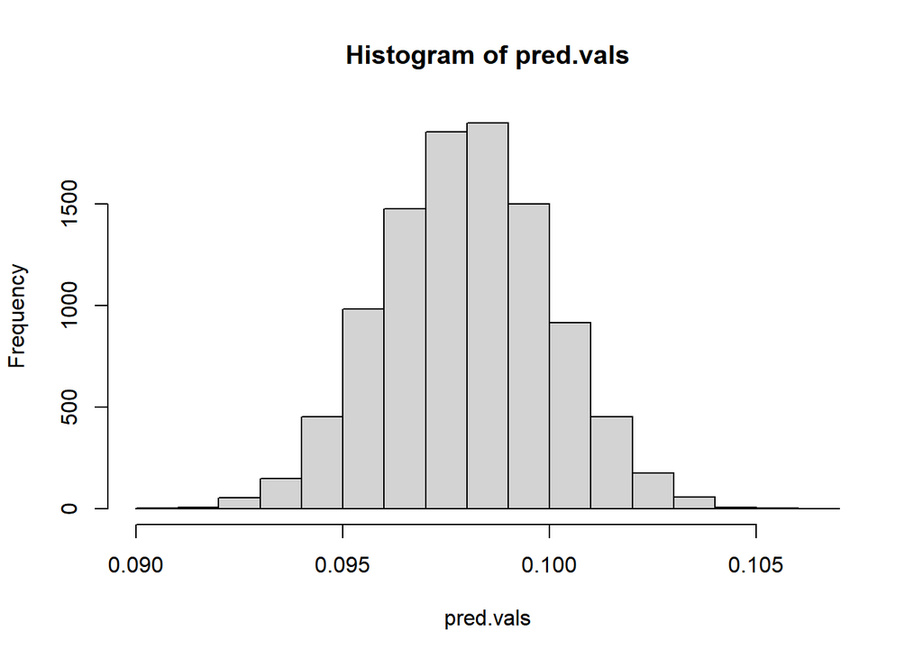

```r
# To generate predicted values, because when treatment.election = 1 then all other
# covariates are zero, we have:
pred.vals <- rnorm(n=10000, mean=coefficients[1], sd=stderrs[1]) + # Intercept
             rnorm(n=10000, mean=coefficients[4], sd=stderrs[4]) # Election treatment

hist(pred.vals)
```

5. Why don’t the predicted values make much sense in the context of the substantive application?

## Problem 2: Logit

Instead of a normal OLS model as in the last question, use a logit model to model `yvar` as a function of `treatment.assign`.

1. Write out the stochastic and systematic components for this model.

We model binary outcomes as Bernoulli trials so our stochastic component is:

$$f_B(y_i;\theta_i)=\theta_i^{y_i}(1-\theta_i)^{1-y_i}=
\left\{
\begin{array}{ll}
\theta_i & y_i=1 \\
1-\theta_i & y_i=0
\end{array}
\right.$$

And our systematic component is:

$$\theta_i=\mathrm{logit}^{-1}(x_i^T\beta)=\frac{1}{1+e^{-x_i^T\beta}}$$

2. Derive the log-likelihood.

We take the product of the stochastic component to get our joint probability distribution:

$$Pr(y|\theta)=\prod_{i=1}^n \theta_i^{y_i}(1-\theta_i)^{1-y_i}$$

Which we take the log of to get our log-likelihood:

$$\ln\mathcal{L}(\theta|y)=\sum_{i=1}^n\ln(\frac{e^{-x_i^T\beta^{1-y_i}}}{1+e^{-x_i^T\beta}})$$

3. Optimize the model to find the maximum likelihood estimates for β. Calculate the standard errors for your βˆ’s and present your results in a nicely formatted table.

```r
#function for optimization of logit
binreg<- function(X,y,method="BFGS"){
  X<- cbind(1,X)

  # Get the log-likelihood
  negLL<- function(b,X,y){
    p<-as.vector(1/(1+exp(-X %*% b)))

    return(-sum(y*log(p) + (1-y)*log(1-p)))
  }

  # Get the gradient (score function)
  gradient<- function(b,X,y){
    p <- as.vector(1/(1+exp(-X %*% b)))

    return(-apply(((y - p)*X), 2, sum))
  }

  # Pass our data, log-likelihood, and gradient to optim()
  # which will find the maximum likelihood
  results<- optim(par=rep(1,ncol(X)),
                  fn=negLL,
                  gr=gradient,
                  hessian=T,
                  method=method,
                  X=X,
                  y=y)

  # Pull out the stuff we want and return it
  list(coefficients=results$par,
       stderr=sqrt(diag(solve(results$hessian))),
       var=solve(results$hessian),
       deviance=2*results$value,
       converged=results$convergence==0)
}

# Build our x
x <- as.matrix(df_q1 %>% select(treatment.top2,
                            treatment.partisan,
                            treatment.election))
# Build our y
y <- df_q1$yvar

# Plug in our x and y created earlier
mlebin.fit<-binreg(X=x, y=y)

# Get our logit coefficients
coefficients <- round(mlebin.fit$coefficients,3)
stderrs <- round(mlebin.fit$stderr,3)

kable(cbind(Term=c("Intercept", "Top-two", "Partisan", "Election"),
      Estimate=coefficients, "Std. Err."=stderrs))
```

| Term | Estimate | Std. Err. |
| --- | --- | --- |
| Intercept | -2.276 | 0.002 |
| Top-two | 0.047 | 0.014 |
| Partisan | 0.065 | 0.014 |
| Election | 0.055 | 0.02 |

```r
# Compare to R's baked in logit estimation
fit.glm <- glm(yvar ~ treatment.top2 + treatment.partisan + treatment.election,
               family = binomial(link = "logit"),
               data = df_q1)
summary(fit.glm)
```

```
##
## Call:
## glm(formula = yvar ~ treatment.top2 + treatment.partisan + treatment.election,
##     family = binomial(link = "logit"), data = df_q1)
##
## Deviance Residuals:
##     Min       1Q   Median       3Q      Max
## -0.4551  -0.4421  -0.4421  -0.4421   2.1789
##
## Coefficients:
##                     Estimate Std. Error   z value Pr(>|z|)
## (Intercept)        -2.276065   0.001783 -1276.199  < 2e-16 ***
## treatment.top2      0.052121   0.013887     3.753 0.000175 ***
## treatment.partisan  0.060760   0.013839     4.390 1.13e-05 ***
## treatment.election  0.057655   0.019528     2.952 0.003153 **
## ---
## Signif. codes:  0 '***' 0.001 '**' 0.01 '*' 0.05 '.' 0.1 ' ' 1
##
## (Dispersion parameter for binomial family taken to be 1)
##
##     Null deviance: 2401883  on 3872267  degrees of freedom
## Residual deviance: 2401842  on 3872264  degrees of freedom
## AIC: 2401850
##
## Number of Fisher Scoring iterations: 5
```

4. Generate a histogram of 10,000 *expected* values for the probability of turning out under the Election treatment. Do the same for the control treatment. Plot the two distributions of probabilities next to one another. Why is the uncertainty different in each of the histograms? On average, how much did the treatment increase the probability of turnout?

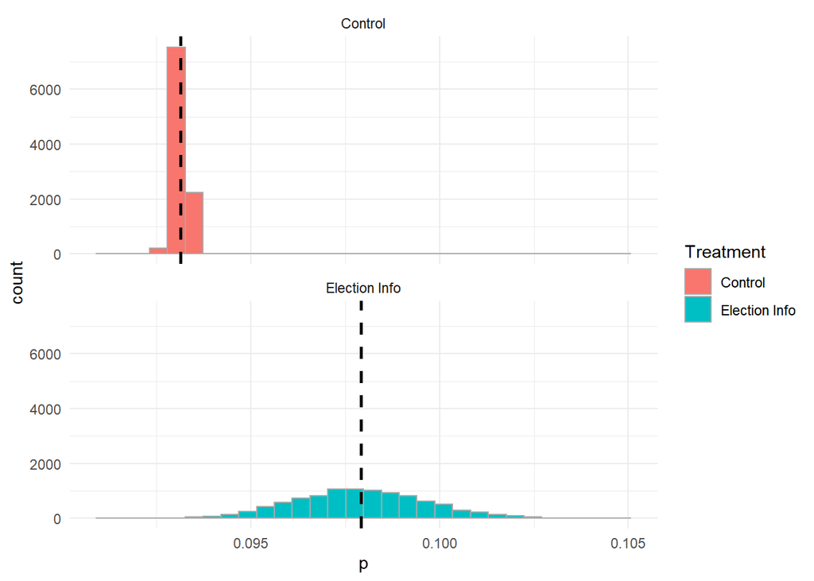

```r
Y.election <- rnorm(n=10000, mean=coefficients[1], sd=stderrs[1]) +
              rnorm(n=10000, mean=coefficients[4], sd=stderrs[4])

P.election <- inv.logit(Y.election)

Y.control <- rnorm(n=10000, mean=coefficients[1], sd=stderrs[1])

P.control <- inv.logit(Y.control)

df_q2.4 <- data.frame(p=c(P.election, P.control),
                      mu=rep(c(mean(P.election), mean(P.control)), each=10000),
                      Treatment=rep(c("Election Info", "Control"), each=10000))

ggplot(data=df_q2.4, aes(x=p, fill=Treatment)) +
  geom_histogram(color="darkgray") +
  geom_vline(aes(xintercept=mu), linetype="dashed", size=1) +
  theme_minimal() +
  facet_wrap(~Treatment, nrow=2)
```

5. In a target population of 3.7 million voters, approximately how many more voters would the Election treatment have gotten to vote than the control?

```r
cat("Election treatment would get:", round(unique(df_q2.4$mu)[[1]]*3.7e6), "voters\n")
```

```
## Election treatment would get: 362266 voters
```

```r
cat("Control would get:", round(unique(df_q2.4$mu)[[2]]*3.7e6), "votSers\n")
```

```
## Control would get: 344597 votSers
```

```r
cat("So a difference of:",
    round(unique(df_q2.4$mu)[[1]]*3.7e6) - round(unique(df_q2.4$mu)[[2]]*3.7e6),
    "voters")
```

```
## So a difference of: 17669 voters
```

## Problem 3: Poisson

In this problem, we will reproduce a simplified version of the analysis from Levin, Jamie, et al. “A test of the democratic peacekeeping hypothesis: Coups, democracy, and foreign military deployments.” *Journal of Peace Research* 58.3 (2021): 355-367. Levin et al hypothesize that sending peacekeepers abroad can undermine authoritarian regimes at home by enriching the military and therefore creating incentives for coups. The authors use a Poisson regression to look at the relationship between peacekeepers sent abroad and the number of coups at home. The authors include a lot of components in the model – here we will simply look at whether the number of military coup attemps `milcoupsum` is predicted by the number of peacekeeping troops sent abroad `troops` using a Poisson regression, controlling for `conflict`.

1. Write out the stochastic and systematic components for the model.

Stochastic component:
$$Y\sim f_p(y;\lambda,h)$$
$$Pr(Y=y)=\frac{e^{-h\lambda}(h\lambda)^y}{y!}$$
where $\lambda>0, h>0$

Systematic component: A linear combination of $X$, $\beta X$

2. Derive the log-likelihood.

To incorporate covariates into a Poisson model where the mean is greater than zero, we need a link function to map our covariates, $x_i$, onto positive values. We use the exponential function:

$$E[Y_i]=h\lambda_i=he^{x_i^T\beta}$$

Or when $h=1$:

$$E[Y_i]=\lambda_i=e^{x_i^T\beta}$$

Plugging this value of $\lambda$ into our probability mass function we found defined above we get:

$$Pr(Y_i=y|x_i)=\frac{e^{-e^{x_i^T\beta}}[e^{x_i^T\beta}]^y} {y!}$$

We then derive the likelihood as follows:

$$\mathcal{L}(\beta|X,y)=\prod_{i=1}^n\frac{e^{-e^{x_i^T\beta}}[e^{x_i^T \beta}]^{y_i}}{y_i!}$$

3. Load the data (`replication_data.dta`) using the `haven` package. Subset the data to only autocracies (`robust_autocracy6`==1). Select only the troops, conflict, and milcoupsum columns of the data. Remove any observations with `NA`’s in either of these columns.

```r
df_q3 <- read_dta("MLE_Midterm_Data/replication_data.dta") %>%
  filter(robust_autocracy6==1) %>%
  select(troops, conflict, milcoupsum) %>%
  drop_na()
```

4. Optimize the model to find the maximum likelihood estimates for β. Calculate the standard errors for your $\hat{\beta}$’s and present your results in a nicely formatted table.

```r
X <- cbind(1,df_q3 %>% select(troops, conflict))
y <- df_q3$milcoupsum

negLL.poisson <- function(par, y, X){
  X <- as.matrix(X)
  beta <- par[1:ncol(X)]

  return(-sum((X%*%beta)*y - exp(X%*%beta)))
}

fit.poisson <- optim(par = rep(0, ncol(X)), fn = negLL.poisson, y = y,
                X = X, method = "BFGS", hessian = TRUE)

coefficients <- round(fit.poisson$par,3)
stderrs <- round(sqrt(diag(solve(fit.poisson$hessian))),3)



kable(cbind(Term=c("Intercept", "Troops", "Conflict"),
      Estimate=coefficients, "Std. Err."=stderrs))
```

| Term | Estimate | Std. Err. |
| --- | --- | --- |
| Intercept | -3.507 | 0.249 |
| Troops | 0.268 | 0.145 |
| Conflict | 1.397 | 0.356 |

```r
# Compare to R's baked in logit estimation
fit.glm <- glm(milcoupsum ~ troops + conflict,
               family = "poisson",
               data = df_q3)
summary(fit.glm)
```

```
##
## Call:
## glm(formula = milcoupsum ~ troops + conflict, family = "poisson",
##     data = df_q3)
##
## Deviance Residuals:
##     Min       1Q   Median       3Q      Max
## -0.7356  -0.2454  -0.2449  -0.2449   3.5863
##
## Coefficients:
##             Estimate Std. Error z value Pr(>|z|)
## (Intercept)  -3.5073     0.2494 -14.062  < 2e-16 ***
## troops        0.2684     0.1448   1.855   0.0637 .
## conflict      1.3972     0.3557   3.929 8.55e-05 ***
## ---
## Signif. codes:  0 '***' 0.001 '**' 0.01 '*' 0.05 '.' 0.1 ' ' 1
##
## (Dispersion parameter for poisson family taken to be 1)
##
##     Null deviance: 209.85  on 654  degrees of freedom
## Residual deviance: 194.05  on 652  degrees of freedom
## AIC: 255.73
##
## Number of Fisher Scoring iterations: 6
```

5. Generate a histogram of 10000 predicted values for coups when `troops`=5 and `conflict`=1. Plot this histogram next to 10000 predicted values for coups when `troops`=0 and `conflict`=1. About how many more coups would you expect with `troops`=5 than `troops`=0?

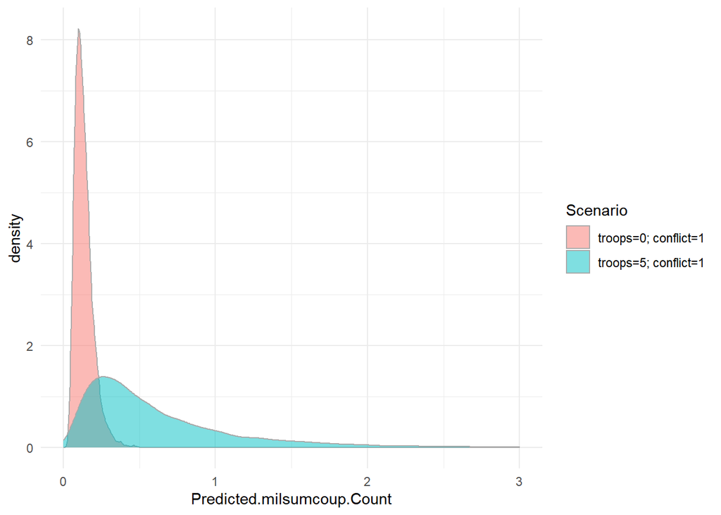

```r
n <- 10000
scen1 <- exp(rnorm(n, mean=coefficients[1], sd=stderrs[1]) +
             5*rnorm(n, mean=coefficients[2], sd=stderrs[2]) +
             1*rnorm(n, mean=coefficients[3], sd=stderrs[3]))

scen2 <- exp(rnorm(n, mean=coefficients[1], sd=stderrs[1]) + 0 +
             1*rnorm(n, mean=coefficients[3], sd=stderrs[3]))

df_q2.5 <- data.frame("Predicted milsumcoup Count"=c(scen1, scen2),
                      "Scenario"=rep(c("troops=5; conflict=1",
                                       "troops=0; conflict=1"),each=n))

ggplot(data=df_q2.5, aes(x=Predicted.milsumcoup.Count,fill=Scenario)) +
  geom_density(color="darkgray", alpha=0.5, position="identity") +
  xlim(c(0,3)) +
  theme_minimal()
```

[figure not shown]

```r
df_scen1 <- data.frame(troops = rep(5, 10000), conflict=rep(1, 10000))
df_scen2 <- data.frame(troops = rep(0, 10000), conflict=rep(1, 10000))

df_scen1$milcoupsum <- exp(predict.glm(fit.glm, df_scen1))
df_scen2$milcoupsum <- exp(predict.glm(fit.glm, df_scen2))

df_scen1$scenario <- "troops=5; conflict=1"
df_scen2$scenario <- "troops=0; conflict=0"

df_q2.5 <- rbind(df_scen1, df_scen2)

ggplot(data=df_q2.5, aes(x=milcoupsum,fill=scenario)) +
  geom_density(color="darkgray", alpha=0.5, position="identity") +
  xlim(c(0,1)) +
  theme_minimal()
```

6. Use the `AER` package to test for overdispersion. What do you conclude?

```r
AER::dispersiontest(fit.glm, alternative="greater")
```

```
##
##  Overdispersion test
##
## data:  fit.glm
## z = 1.8098, p-value = 0.03516
## alternative hypothesis: true dispersion is greater than 1
## sample estimates:
## dispersion
##   1.255613
```

The test indicates there is likely overdispersion in the data. This may be causing our standard errors to be biased toward zero and indicates a quasipoisson or negative binomial model may be a better choice for estimating the relationship between the variables.